# corr EDA options

06 February 2022

## Exploring Correlations

I’ve been dealing with some fairly wide data sets (70-100 columns), and trying to get a sense of the correlations between so many variables and my target has been challenging. In looking for some alternatives to a really big table or heatmap, I’ve put together these three options using a small portion of the FIFA data set.

I’m sure there are better and cleaner ways to do these things, feel free to suggest alternatives!

### Grouped scatterplots

Starting with a simple scatter plot, select the outcome variable and any comparisons you want to see. This is a cleaner way to combine sets of variables and into more easily digestible chunks.

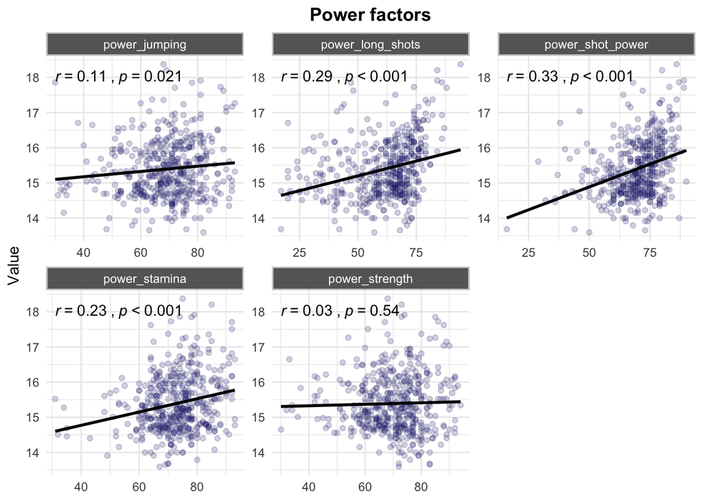

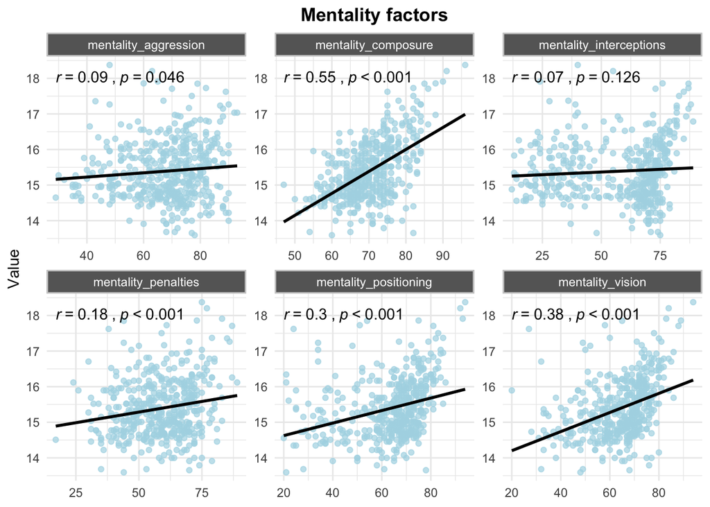

### Barplot of all correlations

This is a way to see the correlation coefficients, with colored bars indicating statistical significance.

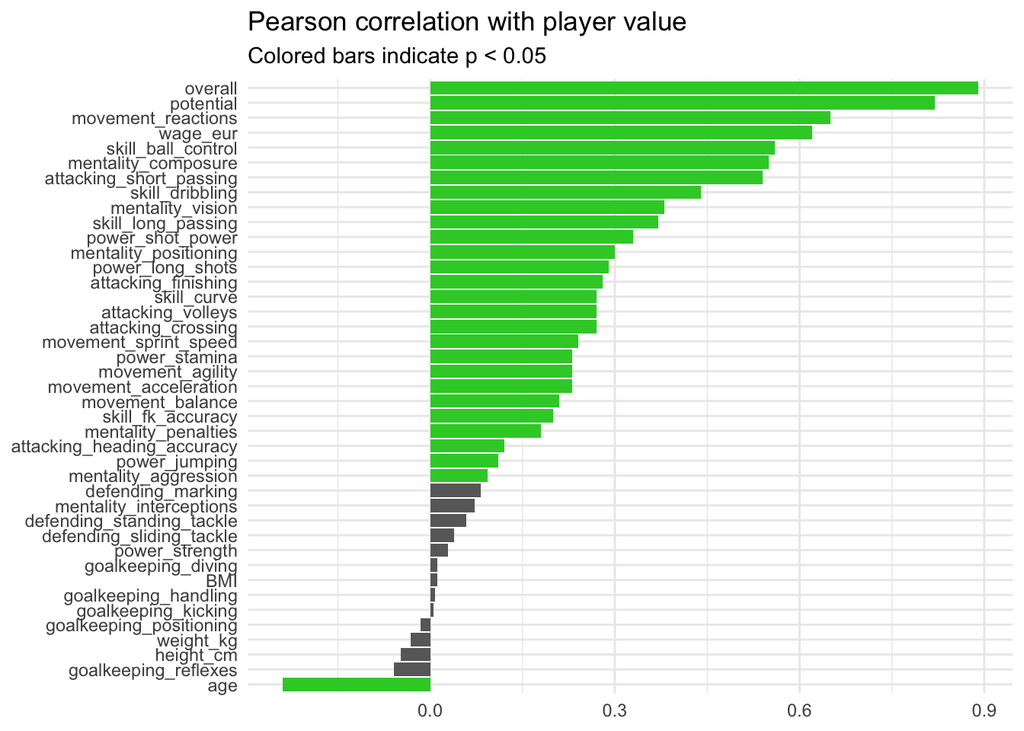

### Dendrogram

I saw a [really cool paper](https://arxiv.org/pdf/2105.06811.pdf) that used agglomerative clustering of features by their correlations to produce a dendrogram. This is seemed like a really creative way to show a lot of variables.

There are several ways to make a dendrogram in r. I wanted to color the variables according to their clusters, which is easy using {dendextend}, but I also preferred to use ggplot. For that we can use {ggdendro}, but there wasn’t an easy way to color according to subgroups. This should be simple enough, but I struggled to find a simple way so I had to get a bit creative.

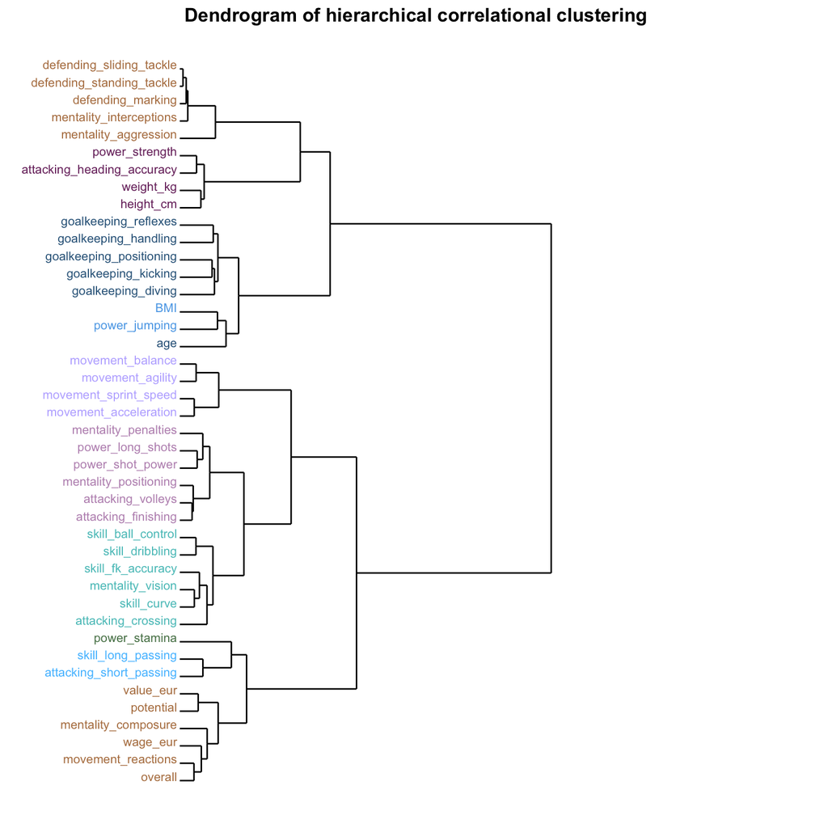